# Prédiction d'une classification binaire :

## Groupe AB

### I/ Introduction :

L'ensemble de données sein-cancer-wisconsin est un ensemble de données de référence bien connu en apprentissage automatique qui contient des informations sur les tumeurs du cancer du sein. Il a été recueilli à l'origine par le Dr William H. Wolberg à l'hôpital de l'Université du Wisconsin, à Madison, au début des années 1990.

L'ensemble de données contient 569 instances, chacune représentant un échantillon de tumeur. Il y a 30 caractéristiques, qui sont des mesures numériques des caractéristiques des noyaux cellulaires présents dans l'échantillon, y compris le rayon moyen, la texture moyenne, le périmètre moyen, la surface moyenne, le lissé moyen, la compacité moyenne, la concavité moyenne, les points concaves moyens, la symétrie moyenne, dimension fractale moyenne, et leurs erreurs standard, et les pires valeurs.

La variable cible est le diagnostic, qui peut être bénin (non cancéreux) ou malin (cancéreux), indiqué par les valeurs 0 et 1, respectivement.

#### II/ Lire et analyser les données :

1. Importation des bibliothéques :

```python
import pandas as pd
import matplotlib.pyplot as plt
import numpy as np
import seaborn as sns

from sklearn.model_selection import train_test_split, cross_val_predict
from sklearn.metrics import accuracy_score,precision_score, recall_score, f1_score, roc_auc_score, confusion_matrix, ConfusionMatrixDisplay
import statsmodels.api as sm


from sklearn.linear_model import LogisticRegression
from catboost import CatBoostClassifier
from lightgbm import LGBMClassifier
from sklearn.ensemble import GradientBoostingClassifier
from sklearn.ensemble import AdaBoostClassifier
from sklearn.svm import SVC
from sklearn.discriminant_analysis import LinearDiscriminantAnalysis
from sklearn.ensemble import RandomForestClassifier


import warnings
warnings.filterwarnings("ignore")
```

1. Importation de la base :

```python
path = "/kaggle/input/breast-cancer-wisconsin-data/data.csv"
df = pd.read_csv(path)
```

```python
df.head()
```

|  | id | diagnosis | radius_mean | texture_mean | perimeter_mean | area_mean | smoothness_mean | compactness_mean | concavity_mean | concave points_mean | ... | texture_worst | perimeter_worst | area_worst | smoothness_worst | compactness_worst | concavity_worst | concave points_worst | symmetry_worst | fractal_dimension_worst | Unnamed: 32 |
| --- | --- | --- | --- | --- | --- | --- | --- | --- | --- | --- | --- | --- | --- | --- | --- | --- | --- | --- | --- | --- | --- |
| 0 | 842302 | M | 17.99 | 10.38 | 122.80 | 1001.0 | 0.11840 | 0.27760 | 0.3001 | 0.14710 | ... | 17.33 | 184.60 | 2019.0 | 0.1622 | 0.6656 | 0.7119 | 0.2654 | 0.4601 | 0.11890 | NaN |
| 1 | 842517 | M | 20.57 | 17.77 | 132.90 | 1326.0 | 0.08474 | 0.07864 | 0.0869 | 0.07017 | ... | 23.41 | 158.80 | 1956.0 | 0.1238 | 0.1866 | 0.2416 | 0.1860 | 0.2750 | 0.08902 | NaN |
| 2 | 84300903 | M | 19.69 | 21.25 | 130.00 | 1203.0 | 0.10960 | 0.15990 | 0.1974 | 0.12790 | ... | 25.53 | 152.50 | 1709.0 | 0.1444 | 0.4245 | 0.4504 | 0.2430 | 0.3613 | 0.08758 | NaN |
| 3 | 84348301 | M | 11.42 | 20.38 | 77.58 | 386.1 | 0.14250 | 0.28390 | 0.2414 | 0.10520 | ... | 26.50 | 98.87 | 567.7 | 0.2098 | 0.8663 | 0.6869 | 0.2575 | 0.6638 | 0.17300 | NaN |
| 4 | 84358402 | M | 20.29 | 14.34 | 135.10 | 1297.0 | 0.10030 | 0.13280 | 0.1980 | 0.10430 | ... | 16.67 | 152.20 | 1575.0 | 0.1374 | 0.2050 | 0.4000 | 0.1625 | 0.2364 | 0.07678 | NaN |

5 rows × 33 columns

```python
df.isnull().sum()
```

```
id                           0
diagnosis                    0
radius_mean                  0
texture_mean                 0
perimeter_mean               0
area_mean                    0
smoothness_mean              0
compactness_mean             0
concavity_mean               0
concave points_mean          0
symmetry_mean                0
fractal_dimension_mean       0
radius_se                    0
texture_se                   0
perimeter_se                 0
area_se                      0
smoothness_se                0
compactness_se               0
concavity_se                 0
concave points_se            0
symmetry_se                  0
fractal_dimension_se         0
radius_worst                 0
texture_worst                0
perimeter_worst              0
area_worst                   0
smoothness_worst             0
compactness_worst            0
concavity_worst              0
concave points_worst         0
symmetry_worst               0
fractal_dimension_worst      0
Unnamed: 32                569
dtype: int64
```

```python
y = df["diagnosis"]
X = df.drop(["id", "Unnamed: 32","diagnosis"], axis = 1)
y.replace(["M","B"],[1,0], inplace = True)
X.info()
```

```
<class 'pandas.core.frame.DataFrame'>
RangeIndex: 569 entries, 0 to 568
Data columns (total 30 columns):
 #   Column                   Non-Null Count  Dtype
---  ------                   --------------  -----
 0   radius_mean              569 non-null    float64
 1   texture_mean             569 non-null    float64
 2   perimeter_mean           569 non-null    float64
 3   area_mean                569 non-null    float64
 4   smoothness_mean          569 non-null    float64
 5   compactness_mean         569 non-null    float64
 6   concavity_mean           569 non-null    float64
 7   concave points_mean      569 non-null    float64
 8   symmetry_mean            569 non-null    float64
 9   fractal_dimension_mean   569 non-null    float64
```

[output cut: 22 more lines]

```python
X.describe()
```

|  | radius_mean | texture_mean | perimeter_mean | area_mean | smoothness_mean | compactness_mean | concavity_mean | concave points_mean | symmetry_mean | fractal_dimension_mean | ... | radius_worst | texture_worst | perimeter_worst | area_worst | smoothness_worst | compactness_worst | concavity_worst | concave points_worst | symmetry_worst | fractal_dimension_worst |
| --- | --- | --- | --- | --- | --- | --- | --- | --- | --- | --- | --- | --- | --- | --- | --- | --- | --- | --- | --- | --- | --- |
| count | 569.000000 | 569.000000 | 569.000000 | 569.000000 | 569.000000 | 569.000000 | 569.000000 | 569.000000 | 569.000000 | 569.000000 | ... | 569.000000 | 569.000000 | 569.000000 | 569.000000 | 569.000000 | 569.000000 | 569.000000 | 569.000000 | 569.000000 | 569.000000 |
| mean | 14.127292 | 19.289649 | 91.969033 | 654.889104 | 0.096360 | 0.104341 | 0.088799 | 0.048919 | 0.181162 | 0.062798 | ... | 16.269190 | 25.677223 | 107.261213 | 880.583128 | 0.132369 | 0.254265 | 0.272188 | 0.114606 | 0.290076 | 0.083946 |
| std | 3.524049 | 4.301036 | 24.298981 | 351.914129 | 0.014064 | 0.052813 | 0.079720 | 0.038803 | 0.027414 | 0.007060 | ... | 4.833242 | 6.146258 | 33.602542 | 569.356993 | 0.022832 | 0.157336 | 0.208624 | 0.065732 | 0.061867 | 0.018061 |
| min | 6.981000 | 9.710000 | 43.790000 | 143.500000 | 0.052630 | 0.019380 | 0.000000 | 0.000000 | 0.106000 | 0.049960 | ... | 7.930000 | 12.020000 | 50.410000 | 185.200000 | 0.071170 | 0.027290 | 0.000000 | 0.000000 | 0.156500 | 0.055040 |
| 25% | 11.700000 | 16.170000 | 75.170000 | 420.300000 | 0.086370 | 0.064920 | 0.029560 | 0.020310 | 0.161900 | 0.057700 | ... | 13.010000 | 21.080000 | 84.110000 | 515.300000 | 0.116600 | 0.147200 | 0.114500 | 0.064930 | 0.250400 | 0.071460 |
| 50% | 13.370000 | 18.840000 | 86.240000 | 551.100000 | 0.095870 | 0.092630 | 0.061540 | 0.033500 | 0.179200 | 0.061540 | ... | 14.970000 | 25.410000 | 97.660000 | 686.500000 | 0.131300 | 0.211900 | 0.226700 | 0.099930 | 0.282200 | 0.080040 |
| 75% | 15.780000 | 21.800000 | 104.100000 | 782.700000 | 0.105300 | 0.130400 | 0.130700 | 0.074000 | 0.195700 | 0.066120 | ... | 18.790000 | 29.720000 | 125.400000 | 1084.000000 | 0.146000 | 0.339100 | 0.382900 | 0.161400 | 0.317900 | 0.092080 |
| max | 28.110000 | 39.280000 | 188.500000 | 2501.000000 | 0.163400 | 0.345400 | 0.426800 | 0.201200 | 0.304000 | 0.097440 | ... | 36.040000 | 49.540000 | 251.200000 | 4254.000000 | 0.222600 | 1.058000 | 1.252000 | 0.291000 | 0.663800 | 0.207500 |

8 rows × 30 columns

1. Visualisation de la base :

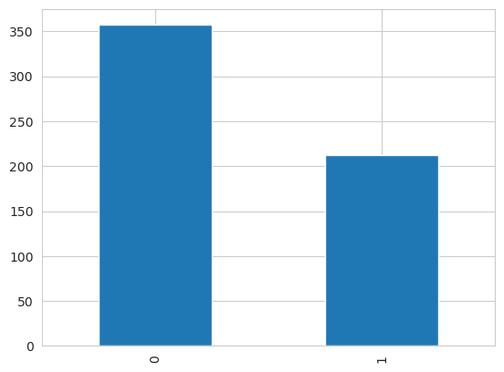

```python
X = (X - X.mean())/X.std()
y_count = y.value_counts()
y_count.plot(kind='bar')
```

```python
percent_0 = np.sum(y== 0) / len(y) * 100
percent_1 = np.sum(y == 1) / len(y) * 100

print(f"Percentage of 0s: {percent_0:.2f}%")
print(f"Percentage of 1s: {percent_1:.2f}%")
```

```
Percentage of 0s: 62.74%
Percentage of 1s: 37.26%
```

Le jeu de données Breast Cancer Wisconsin (Diagnostic) n'est pas équilibré car la proportion de la classe 0 (bénigne) est environ 63% et la proportion de la classe 1 (maligne) est environ 37%.

Ce code permet de créer un graphique en violon (violin plot) pour visualiser la distribution des features de l'ensemble de données Diagnostic, en fonction de la variable cible "diagnosis".

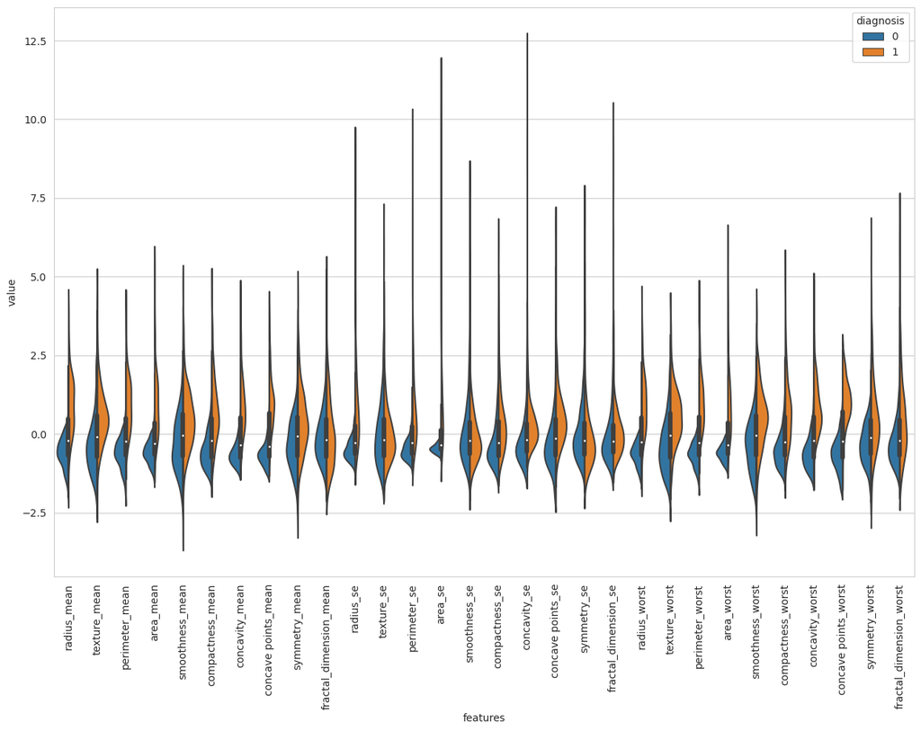

```python
X = (X - X.mean())/X.std()
data = pd.concat([y,X.iloc[:,:]],axis=1)
data = pd.melt(data,id_vars="diagnosis",
                    var_name="features",
                    value_name='value')
plt.figure(figsize=(15,10))
sns.violinplot(data = data, x="features", y="value", hue="diagnosis",split=True)
plt.xticks(rotation=90)
plt.show()
```

On a si les distributions des valeurs pour une caractéristique sont nettement séparées pour les deux classes de la variable cible "diagnosis", cela suggère que cette caractéristique a un pouvoir prédictif élevé pour la classification. En effet, une caractéristique qui peut séparer nettement les classes est utile pour l'apprentissage automatique, car elle peut aider un algorithme de classification à distinguer les deux classes et à prendre des décisions de classification précises.

Dans le cas des variables "radius_mean" et "concavity_mean", nous pouvons voir que les valeurs pour la classe maligne (classe 1) sont généralement plus élevées que pour la classe bénigne (classe 0), ce qui suggère que ces caractéristiques peuvent être utiles pour prédire la malignité des tumeurs.

1. Visualisation de feature numerique :

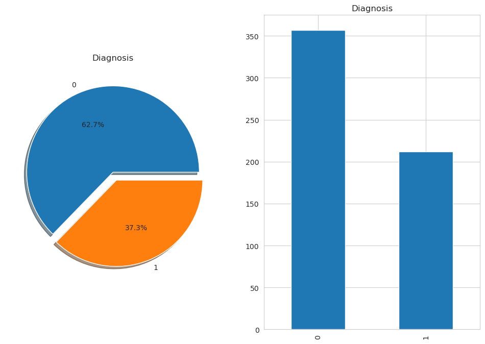

```python
f,ax=plt.subplots(1,2,figsize=(12,8))
y.value_counts().plot.pie(explode=[0,0.1],autopct='%1.1f%%',ax=ax[0],shadow=True)
ax[0].set_title('Diagnosis')
ax[0].set_ylabel('')
y_count = y.value_counts()
y_count.plot(kind='bar')
ax[1].set_title('Diagnosis')
plt.show()
```

```python
from sklearn.feature_selection import RFECV,chi2
rfecv = RFECV(estimator=RandomForestClassifier(), cv=5,scoring='accuracy', step=1)
rfecv = rfecv.fit(X, y)
print('Optimal number of features :', rfecv.n_features_)
print('Using RFECV the Best features are :', X.columns[rfecv.support_])
```

```
Optimal number of features : 17
Using RFECV the Best features are : Index(['radius_mean', 'texture_mean', 'perimeter_mean', 'area_mean',
       'concavity_mean', 'concave points_mean', 'radius_se', 'area_se',
       'radius_worst', 'texture_worst', 'perimeter_worst', 'area_worst',
       'smoothness_worst', 'compactness_worst', 'concavity_worst',
       'concave points_worst', 'symmetry_worst'],
      dtype='object')
```

L'élimination récursive de caractéristiques avec validation croisée (RFECV) est une méthode de sélection de caractéristiques qui utilise une combinaison d'élimination récursive de caractéristiques et de validation croisée pour identifier les caractéristiques les plus importantes dans un jeu de données. Cette méthode est souvent utilisée dans l'apprentissage automatique pour réduire la dimensionnalité de l'espace des caractéristiques et améliorer la précision des modèles.

[output not shown]

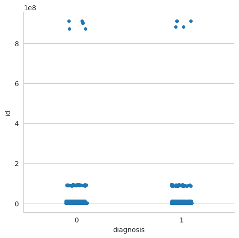

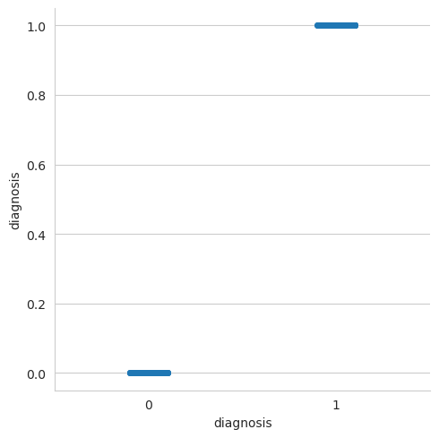

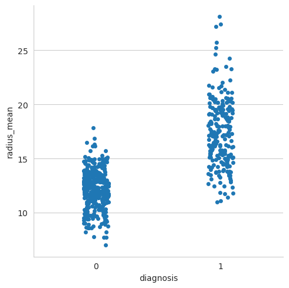

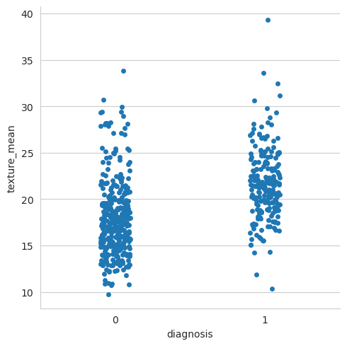

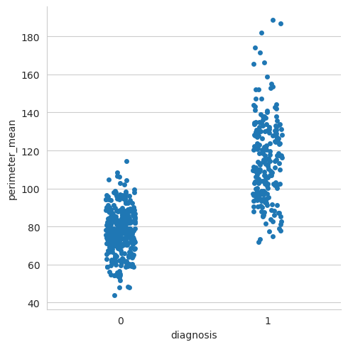

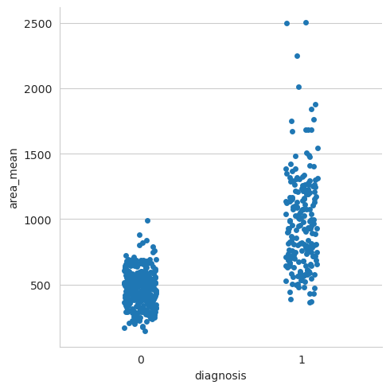

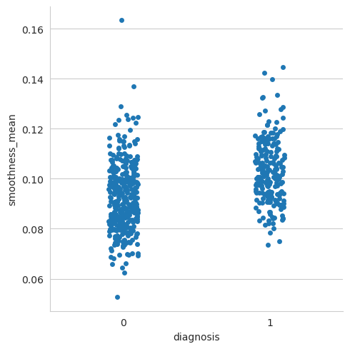

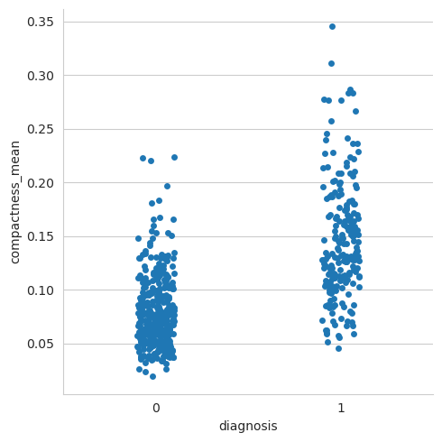

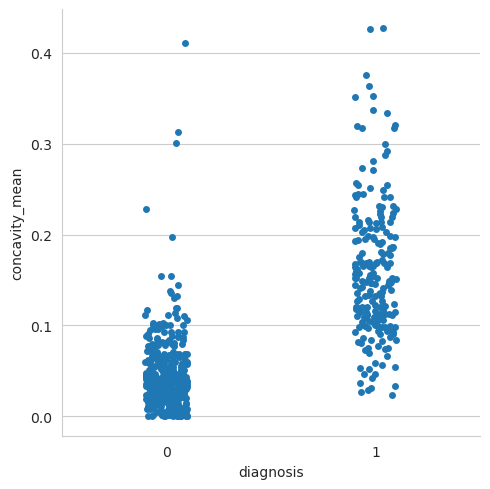

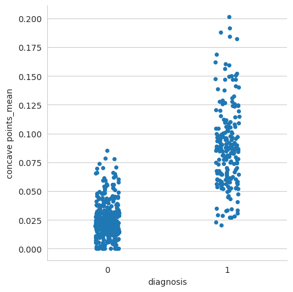

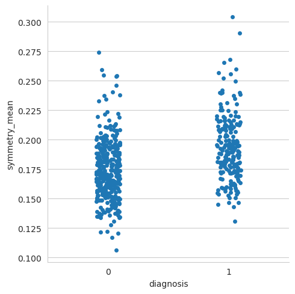

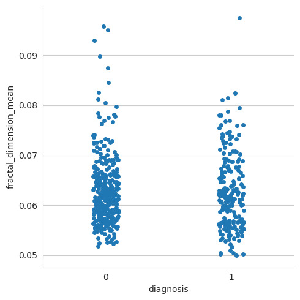

[21 more figures not shown]

```python
sns.set_style("whitegrid")
for col in df:
    sns.catplot(data=df, x=y, y=col, kind='strip')
plt.show()
```

```python
for col in df:
    data=df[col]
    q1 = np.percentile(df, 25)
    q3 = np.percentile(df, 75)
    iqr = q3 - q1

    lower = q1 - 1.5 * iqr
    upper = q3 + 1.5* iqr

    outlier = pd.Series(data)[(data < lower) | (data > upper)]

# Print outliers
    print("Outliers in",col)
    print(outlier.shape)
```

```
Outliers in id
(0,)
Outliers in diagnosis
(0,)
Outliers in radius_mean
(0,)
Outliers in texture_mean
(0,)
Outliers in perimeter_mean
(0,)
Outliers in area_mean
(0,)
Outliers in smoothness_mean
(0,)
Outliers in compactness_mean
(0,)
Outliers in concavity_mean
(0,)
Outliers in concave points_mean
(0,)
Outliers in symmetry_mean
(0,)
Outliers in fractal_dimension_mean
(0,)
Outliers in radius_se
(0,)
Outliers in texture_se
(0,)
Outliers in perimeter_se
(0,)
Outliers in area_se
(0,)
Outliers in smoothness_se
(0,)
Outliers in compactness_se
(0,)
Outliers in concavity_se
(0,)
Outliers in concave points_se
(0,)
```

[output cut: 11 more lines]

```
(0,)
Outliers in smoothness_worst
(0,)
Outliers in compactness_worst
(0,)
Outliers in concavity_worst
(0,)
Outliers in concave points_worst
(0,)
Outliers in symmetry_worst
(0,)
Outliers in fractal_dimension_worst
(0,)
Outliers in Unnamed: 32
(0,)
```

### Selectkbest

- SelectKBest est une technique de sélection de fonctionnalités utilisée pour sélectionner les k meilleures fonctionnalités (ou variables) à partir d'un ensemble de fonctionnalités en fonction de leur score de qualité (ou importance).
- Plus précisément, SelectKBest calcule un score de qualité pour chaque fonctionnalité en utilisant une fonction de test statistique (telle que ANOVA, chi2, mutual_info_regression, etc.). Ensuite, les k meilleures fonctionnalités sont sélectionnées en fonction de leur score.

```
Index(['radius_mean', 'perimeter_mean', 'area_mean', 'compactness_mean',
       'concavity_mean', 'concave points_mean', 'radius_se', 'perimeter_se',
       'area_se', 'radius_worst', 'perimeter_worst', 'area_worst',
       'compactness_worst', 'concavity_worst', 'concave points_worst'],
      dtype='object')
```

[figure not shown]

```python
from sklearn.feature_selection import SelectKBest, f_classif

# Sélection des 10 meilleures variables
selector = SelectKBest(score_func=f_classif, k=15)
X_new = selector.fit_transform(X, y)

# Affichage des noms des variables sélectionnées
mask = selector.get_support()  # tableau de booléens indiquant les variables sélectionnées
selected_features = X.columns[mask]  # noms des variables sélectionnées
print(selected_features)


# plot the feature scores
fig, ax = plt.subplots(figsize=(10, 8))

sns.barplot(x='Feature', y='Score', data=feature_scores_df, order=sorted_feature_names, ax=ax)
ax.set_xticklabels(ax.get_xticklabels(), rotation=50, ha='right')
ax.set_xlabel('Feature')
ax.set_ylabel('Score')
ax.set_title('Feature Scores')

plt.show()
```

```
t-statistic: 1.599364812413284
p-value: 0.11029660865789295
```

[output not shown]

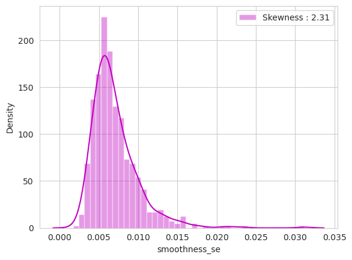

```python
from scipy.stats import ttest_ind
cat_cols = df.columns[16:30]

for col in cat_cols:
    g = sns.distplot(df[col], color="m", label="Skewness : %.2f"%(df[col].skew()))
    g = g.legend(loc="best")
    group0 = df[y == 0][col]
    group1 = df[y == 1][col]

    t_statistic, p_value = ttest_ind(group0, group1)

    print('t-statistic:', t_statistic)
    print('p-value:', p_value)

    contingency_table = pd.crosstab(df[cat_cols], df[col])
    chi2, p, _, _ = chi2_contingency(contingency_table)
    plt.tight_layout()
    plt.show()
```

Les résultats du test t effectué sur la fonctionnalité "smoothness_se" ont montré une valeur p de 0,11, indiquant que cette fonctionnalité n'est pas statistiquement significative.

#### Logistic Regression :

```python
corr = df.corr()
upper = corr.where(np.triu(np.ones(corr.shape), k=1).astype(np.bool))
to_drop = [column for column in upper.columns if any(upper[column] > 0.9)]
X_transformed = X.drop(to_drop, axis=1)
corr.drop(to_drop, inplace=True)
```

```python
corr["diagnosis"].nlargest(11)
```

```
diagnosis            1.000000
radius_mean          0.730029
concavity_mean       0.696360
concavity_worst      0.659610
compactness_mean     0.596534
compactness_worst    0.590998
radius_se            0.567134
smoothness_worst     0.421465
symmetry_worst       0.416294
texture_mean         0.415185
concave points_se    0.408042
Name: diagnosis, dtype: float64
```

```python
cols = corr["diagnosis"].nlargest(11).index[1:]
df = X_transformed[cols]
X_train, X_test, y_train, y_test = train_test_split(df, y, test_size=0.2, random_state=42)
log_reg = sm.Logit(y_train, X_train).fit()
log_reg.summary()
print(log_reg.aic, log_reg.bic)
print(log_reg.wald_test(X_train))
```

```
Optimization terminated successfully.
         Current function value: 0.075588
         Iterations 11
88.78509190186436 129.98806609137387
<Wald test (chi2): statistic=[[47.53623588]], p-value=7.541574197493326e-07, df_denom=10>
```

```python
X_train, X_test, y_train, y_test = train_test_split(df, y, test_size=0.2, random_state=42)

logit_model = sm.Logit(y_train,X_train)
result = logit_model.fit()

wald_test = result.wald_test_terms()

aic = result.aic
bic = result.bic
print(result.summary())
print("AIC:", aic)
print("BIC:", bic)
```

```
Optimization terminated successfully.
         Current function value: 0.075588
         Iterations 11
                           Logit Regression Results
==============================================================================
Dep. Variable:              diagnosis   No. Observations:                  455
Model:                          Logit   Df Residuals:                      445
Method:                           MLE   Df Model:                            9
Date:                Mon, 01 May 2023   Pseudo R-squ.:                  0.8854
Time:                        19:35:21   Log-Likelihood:                -34.393
converged:                       True   LL-Null:                       -300.17
Covariance Type:            nonrobust   LLR p-value:                1.002e-108
=====================================================================================
                        coef    std err          z      P>|z|      [0.025      0.975]
-------------------------------------------------------------------------------------
radius_mean           5.7758      1.085      5.322      0.000       3.649       7.903
concavity_mean        1.8784      1.606      1.170      0.242      -1.269       5.026
concavity_worst       0.9228      1.233      0.748      0.454      -1.494       3.340
compactness_mean     -1.7803      1.363     -1.306      0.192      -4.452       0.892
compactness_worst     0.3044      1.395      0.218      0.827      -2.429       3.038
radius_se             3.4233      0.892      3.840      0.000       1.676       5.171
smoothness_worst      2.5441      0.571      4.452      0.000       1.424       3.664
symmetry_worst        1.3541      0.436      3.106      0.002       0.500       2.209
texture_mean          1.8299      0.406      4.505      0.000       1.034       2.626
concave points_se    -1.1124      0.579     -1.923      0.055      -2.246       0.022
=====================================================================================

Possibly complete quasi-separation: A fraction 0.39 of observations can be
perfectly predicted. This might indicate that there is complete
quasi-separation. In this case some parameters will not be identified.
AIC: 88.78509190186436
BIC: 129.98806609137387
```

```
Accuracy: 0.9824561403508771
Precision: 0.9767441860465116
Recall: 0.9767441860465116
f1_score: 0.9767441860465116
```

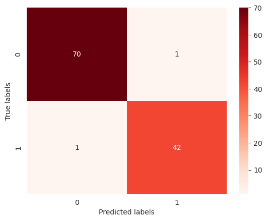

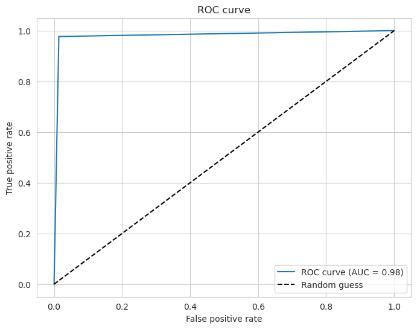

```python
from sklearn.metrics import roc_curve
y_pred = result.predict(X_test)
y_pred_binary = (y_pred >= 0.5).astype(int)

accuracy_lr = accuracy_score(y_test, y_pred_binary)
precision_lr = precision_score(y_test, y_pred_binary)
recall_lr = recall_score(y_test, y_pred_binary)
f1_score_lr=f1_score(y_test, y_pred_binary)
print("Accuracy:", accuracy_lr)
print("Precision:", precision_lr)
print("Recall:", recall_lr)
print("f1_score:", f1_score_lr)
cm = confusion_matrix(y_test, y_pred_binary)


sns.heatmap(cm, annot=True, fmt='d', cmap="Reds")
plt.xlabel("Predicted labels")
plt.ylabel("True labels")
plt.show()


fpr_lr, tpr_lr, thresholds = roc_curve(y_test, y_pred_binary)
auc_lr = roc_auc_score(y_test, y_pred_binary)

sns.set_style('whitegrid')
plt.figure(figsize=(8, 6))
plt.plot(fpr_lr, tpr_lr, label='ROC curve (AUC = {:.2f})'.format(auc_lr))
plt.plot([0, 1], [0, 1], 'k--', label='Random guess')
plt.xlabel('False positive rate')
plt.ylabel('True positive rate')
plt.title('ROC curve')
plt.legend(loc='lower right')
plt.show()
```

On observe une valeur de ROC égale à 0.98 donc il est considérée comme un excellent résultat pour une classification binaire. Cela indique que le modèle a une capacité très élevée à discriminer entre les classes positives et négatives, avec une très faible probabilité de faux positifs et de faux négatifs.

### Decision Tree

```
Accuracy: 0.9210526315789473
Precision: 0.8695652173913043
Recall: 0.9302325581395349
```

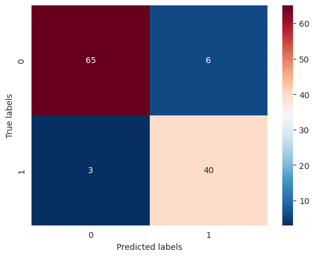

```
AUC: 0.9228627579430069
```

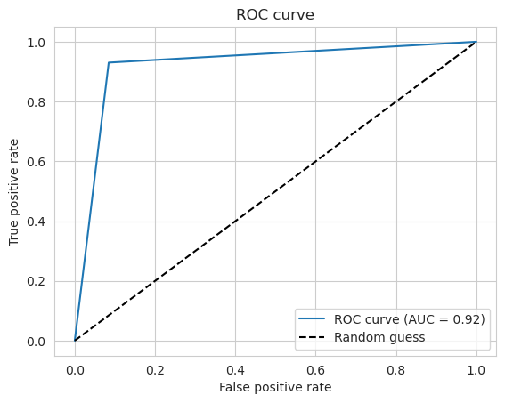

```python
from sklearn.tree import DecisionTreeClassifier
clf = DecisionTreeClassifier(max_depth=3)
clf = clf.fit(X_train,y_train)
y_pred1 = clf.predict(X_test)
accuracy = accuracy_score(y_test, y_pred1)
precision = precision_score(y_test, y_pred1)
recall = recall_score(y_test, y_pred1)
print("Accuracy:", accuracy)
print("Precision:", precision)
print("Recall:", recall)
cm = confusion_matrix(y_test, y_pred1)
sns.heatmap(cm, annot=True, fmt='d', cmap= "RdBu_r")
plt.xlabel("Predicted labels")
plt.ylabel("True labels")
plt.show()
# Compute ROC curve
fpr, tpr, thresholds = roc_curve(y_test, y_pred1)
auc = roc_auc_score(y_test, y_pred1)
print("AUC:", auc)

plt.plot(fpr, tpr, label='ROC curve (AUC = {:.2f})'.format(auc))
plt.plot([0, 1], [0, 1], 'k--', label='Random guess')
plt.xlabel('False positive rate')
plt.ylabel('True positive rate')
plt.title('ROC curve')
plt.legend(loc='lower right')
plt.show()
```

```python
from sklearn.tree import export_graphviz
from graphviz import Source
import graphviz
dot_data = export_graphviz(clf, out_file=None,
                           feature_names=X_train.columns,
                           class_names=['0', '1'],
                           filled=True, rounded=True,
                           special_characters=True)
graphviz.Source(dot_data)
```

[figure not shown]

```python
from sklearn.model_selection import GridSearchCV
dtc = DecisionTreeClassifier()
params = {
    'max_depth': [2,3,7,8,10],
    'min_samples_split': [2, 3, 4,5,7]
}

grid_search = GridSearchCV(dtc, param_grid=params, cv=5)
grid_search.fit(X_train, y_train)

print("Best parameters: ", grid_search.best_params_)
print("Best score: ", grid_search.best_score_)
```

```
Best parameters:  {'max_depth': 8, 'min_samples_split': 2}
Best score:  0.9098901098901099
```

```
Accuracy: 0.9210526315789473
Precision: 0.8863636363636364
Recall: 0.9069767441860465
f1_score: 0.896551724137931
```

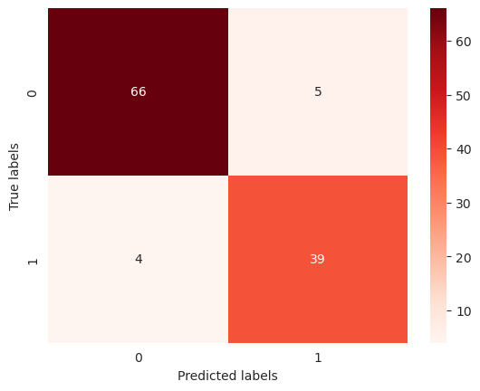

```
AUC: 0.9228627579430069
```

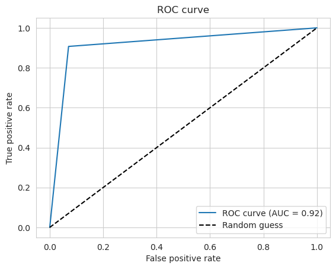

```python
y_pred = grid_search.predict(X_test)
accuracy_dt = accuracy_score(y_test, y_pred)
precision_dt = precision_score(y_test, y_pred)
recall_dt = recall_score(y_test, y_pred)
f1_score_dt = f1_score(y_test, y_pred)
print("Accuracy:", accuracy_dt)
print("Precision:", precision_dt)
print("Recall:", recall_dt)
print("f1_score:", f1_score_dt)
cm = confusion_matrix(y_test, y_pred)

sns.heatmap(cm, annot=True, fmt='d', cmap="Reds")
plt.xlabel("Predicted labels")
plt.ylabel("True labels")
plt.show()
# Compute ROC curve
fpr_dt, tpr_dt, thresholds = roc_curve(y_test, y_pred)
auc_dt = roc_auc_score(y_test, y_pred)
print("AUC:", auc)

# Plot ROC curve
plt.plot(fpr_dt, tpr_dt, label='ROC curve (AUC = {:.2f})'.format(auc_dt))
plt.plot([0, 1], [0, 1], 'k--', label='Random guess')
plt.xlabel('False positive rate')
plt.ylabel('True positive rate')
plt.title('ROC curve')
plt.legend(loc='lower right')
plt.show()
```

### Random Forest

```
Accuracy: 0.956140350877193
Precision: 0.9523809523809523
Recall: 0.9302325581395349
```

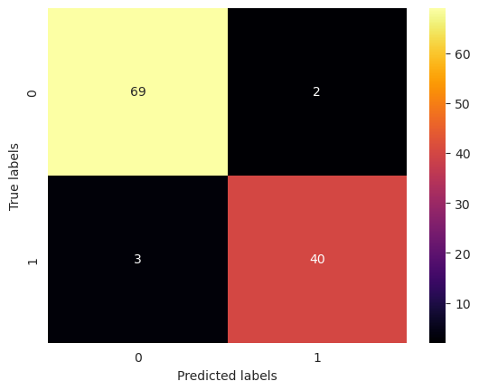

```
AUC: 0.9510317720275139
```

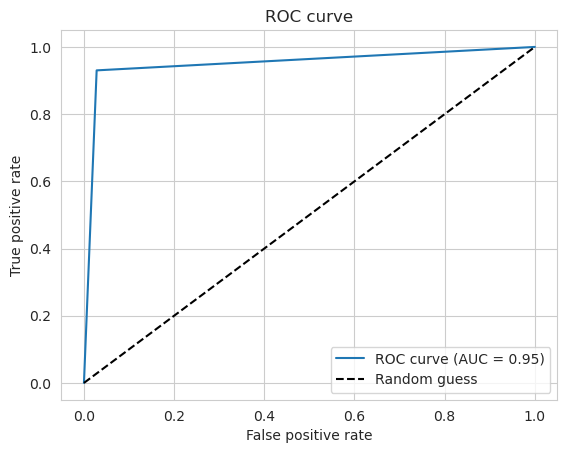

```python
rfc = RandomForestClassifier(n_estimators=3,max_depth=3)
rfc = rfc.fit(X_train,y_train)
y_pred2 = rfc.predict(X_test)
accuracy = accuracy_score(y_test, y_pred2)
precision = precision_score(y_test, y_pred2)
recall = recall_score(y_test, y_pred2)
print("Accuracy:", accuracy)
print("Precision:", precision)
print("Recall:", recall)
cm = confusion_matrix(y_test, y_pred2)

sns.heatmap(cm, annot=True, fmt='d', cmap="inferno")
plt.xlabel("Predicted labels")
plt.ylabel("True labels")
plt.show()
# Compute ROC curve
from sklearn.metrics import roc_curve, roc_auc_score
fpr, tpr, thresholds = roc_curve(y_test, y_pred2)
auc = roc_auc_score(y_test, y_pred2)
print("AUC:", auc)

# Plot ROC curve
plt.plot(fpr, tpr, label='ROC curve (AUC = {:.2f})'.format(auc))
plt.plot([0, 1], [0, 1], 'k--', label='Random guess')
plt.xlabel('False positive rate')
plt.ylabel('True positive rate')
plt.title('ROC curve')
plt.legend(loc='lower right')
plt.show()
```

```python
from sklearn.tree import export_graphviz
from graphviz import Source

for i, tree in enumerate(rfc.estimators_):
    dot_data = export_graphviz(tree, out_file=None,
                               feature_names=X_train.columns,
                               class_names=['0', '1'],
                               filled=True, rounded=True,
                               special_characters=True)
    graph = Source(dot_data)
    display(graph)
```

[figure not shown]

```python
from sklearn.model_selection import StratifiedKFold
kfold = StratifiedKFold(n_splits=10)
RFC = RandomForestClassifier(oob_score=True)


## Search grid for optimal parameters
rf_param_grid = {"max_depth": [None],
              "max_features": [1, 3, 10],
              "min_samples_split": [10],
              "min_samples_leaf": [1, 3, 10],
              "bootstrap": [True],
              "n_estimators" :[700],
              "criterion": ["gini"]}


gsRFC = GridSearchCV(RFC,param_grid = rf_param_grid, cv=kfold, scoring="accuracy", n_jobs= 4, verbose = 1)

gsRFC.fit(X_train,y_train)

RFC_best = gsRFC.best_estimator_

# Best score and oob_score
print(gsRFC.best_score_)
print(RFC_best.oob_score_)
```

```
Fitting 10 folds for each of 9 candidates, totalling 90 fits
0.9428019323671497
0.945054945054945
```

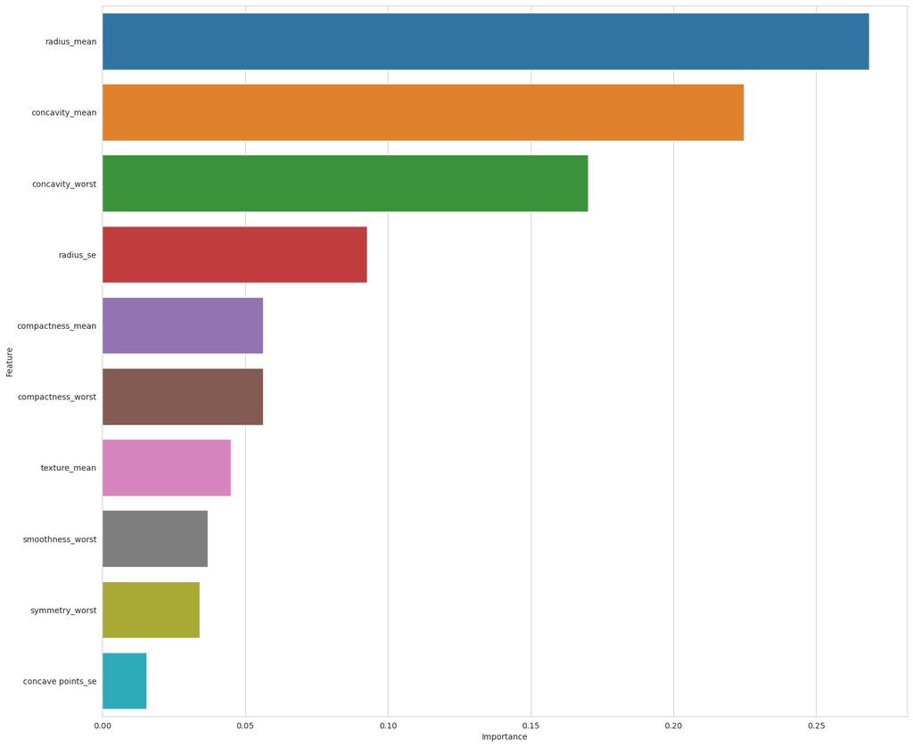

```python
importances = RFC_best.feature_importances_

importances_df = pd.DataFrame({"Feature": X_train.columns,
                               "Importance": importances})

importances_df = importances_df.sort_values(by="Importance", ascending=False)
plt.figure(figsize=(18, 16))

# Create a bar chart of feature importances
sns.barplot(x="Importance", y="Feature", data=importances_df)
plt.show()
```

```
Accuracy: 0.956140350877193
Precision: 0.9523809523809523
Recall: 0.9302325581395349
f1_score: 0.9411764705882352
```

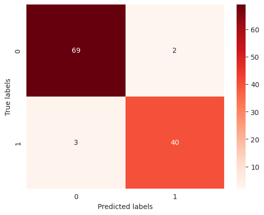

```
AUC: 0.9510317720275139
```

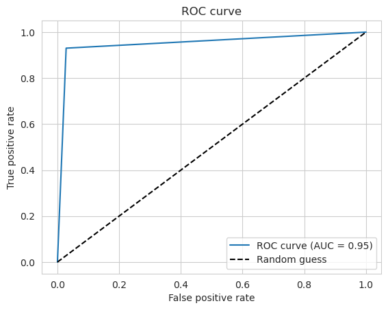

```python
y_pred = RFC_best.predict(X_test)

accuracy_rfc = accuracy_score(y_test, y_pred)
precision_rfc = precision_score(y_test, y_pred)
recall_rfc = recall_score(y_test, y_pred)
f1_score_rfc = f1_score(y_test, y_pred)

print("Accuracy:", accuracy_rfc)
print("Precision:", precision_rfc)
print("Recall:", recall_rfc)
print("f1_score:", f1_score_rfc)
cm = confusion_matrix(y_test, y_pred)

# Plot the confusion matrix as a heatmap

sns.heatmap(cm, annot=True, fmt='d', cmap="Reds")
plt.xlabel("Predicted labels")
plt.ylabel("True labels")
plt.show()
# Compute ROC curve
fpr_rfc, tpr_rfc, thresholds = roc_curve(y_test, y_pred)
auc_rfc = roc_auc_score(y_test, y_pred)
print("AUC:", auc)

# Plot ROC curve
plt.plot(fpr_rfc, tpr_rfc, label='ROC curve (AUC = {:.2f})'.format(auc_rfc))
plt.plot([0, 1], [0, 1], 'k--', label='Random guess')
plt.xlabel('False positive rate')
plt.ylabel('True positive rate')
plt.title('ROC curve')
plt.legend(loc='lower right')
plt.show()
```

### III/ Récapitulation :

```python
from tabulate import tabulate
data = {
    'Model': ['Logistic Regression', 'Decision Tree', 'Random Forest'],
    'Accuracy': [accuracy_lr, accuracy_dt, accuracy_rfc],
    'F1 Score': [f1_score_lr, f1_score_dt, f1_score_rfc],
    'Precision': [precision_lr, precision_dt, precision_rfc],
    'Recall': [recall_lr, recall_dt, recall_rfc],
    'AUC Score': [auc_lr, auc_dt, auc_rfc]
}

# Create a pandas dataframe from the dictionary
df = pd.DataFrame(data)

# Print the dataframe
# Sort the results by Accuracy in descending order
df = df.sort_values('Accuracy', ascending=False)

# Convert the DataFrame to a table and print it
table = tabulate(df, headers='keys', tablefmt="simple", showindex=False)
print(table)
```

```
Model                  Accuracy    F1 Score    Precision    Recall    AUC Score
-------------------  ----------  ----------  -----------  --------  -----------
Logistic Regression    0.982456    0.976744     0.976744  0.976744     0.98133
Random Forest          0.95614     0.941176     0.952381  0.930233     0.951032
Decision Tree          0.921053    0.896552     0.886364  0.906977     0.918277
```

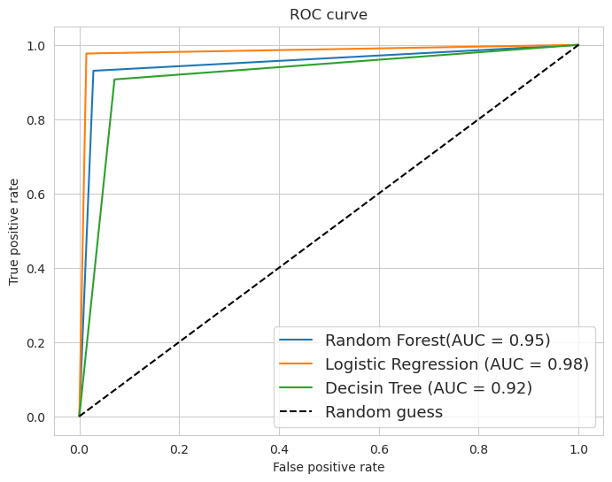

```python
plt.figure(figsize=(20,20))
sns.set_style('whitegrid')
plt.figure(figsize=(8, 6))
plt.plot(fpr_rfc, tpr_rfc, label='Random Forest(AUC = {:.2f})'.format(auc_rfc))
plt.plot(fpr_lr, tpr_lr, label='Logistic Regression (AUC = {:.2f})'.format(auc_lr))
plt.plot(fpr_dt, tpr_dt, label='Decisin Tree (AUC = {:.2f})'.format(auc_dt))
plt.plot([0, 1], [0, 1], 'k--', label='Random guess')
plt.xlabel('False positive rate')
plt.ylabel('True positive rate')
plt.title('ROC curve')
plt.legend(loc='lower right',prop={'size': 13})
plt.show()
```